# pcb_anomaly_detection

## Bölüm 1: Giriş ve Kurulum

Bu bölümde proje bağlamı tanıtılmakta, gerekli kütüphaneler içe aktarılmakta ve tekrarlanabilirlik için rastgele tohumlar ayarlanmaktadır. Bölümün sonunda kullanılan hesaplama cihazı (MPS/CUDA/CPU) ekrana yazdırılacak ve veri seti kök yolu tanımlanacaktır.

```python
# Tekrarlanabilirlik için rastgele tohumları ayarla
import random
import numpy as np
import torch

random.seed(42)
np.random.seed(42)
torch.manual_seed(42)
if torch.cuda.is_available():
    torch.cuda.manual_seed_all(42)

print("Rastgele tohumlar ayarlandı: random=42, numpy=42, torch=42")
```

```
Rastgele tohumlar ayarlandı: random=42, numpy=42, torch=42
```

```python
# Kütüphane içe aktarmaları
import os
import time
import warnings
from pathlib import Path
from typing import List, Tuple, Optional, Dict

import numpy as np
import pandas as pd
import matplotlib.pyplot as plt
import seaborn as sns
from PIL import Image

import torch
import torch.nn as nn
import torch.optim as optim
from torch.utils.data import Dataset, DataLoader, WeightedRandomSampler
import torchvision.transforms as transforms
import torchvision.models as models
from torchvision.models import ResNet18_Weights

from sklearn.model_selection import train_test_split
from sklearn.metrics import (
    accuracy_score, precision_score, recall_score, f1_score,
    confusion_matrix, roc_auc_score, average_precision_score,
    roc_curve, precision_recall_curve
)

# Veri seti kök yolu — farklı ortamlarda bu değişkeni güncelleyin
DATA_ROOT = "dataset/pcb1/Data/Images"

# Hesaplama cihazı seçimi: MPS → CUDA → CPU
if torch.backends.mps.is_available():
    device = torch.device("mps")
elif torch.cuda.is_available():
    device = torch.device("cuda")
else:
    device = torch.device("cpu")
    print("UYARI: GPU bulunamadı, CPU kullanılıyor. Eğitim süresi uzayabilir.")

print(f"Kullanılan cihaz: {device}")
```

```
Kullanılan cihaz: mps
```

## Bölüm 2: Veri Analizi

Bu bölümde PCB görüntü veri seti yüklenmekte, sınıf dağılımı incelenmekte ve veri artırma (augmentation) pipeline'ları tanımlanmaktadır. Bölümün sonunda eğitim/doğrulama/test DataLoader'ları oluşturulacak ve sınıf dengesizliği görselleştirilecektir.

```python
# ── Bölüm 2.1: PCBDataset Sınıfı ──────────────────────────────────────────
class PCBDataset(Dataset):
    """
    PCB görüntü veri seti için PyTorch Dataset sınıfı.
    Normal dizini → etiket 0, Anomaly dizini → etiket 1
    """

    def __init__(self, image_paths: List[str], labels: List[int],
                 transform=None):
        self.image_paths = image_paths
        self.labels = labels
        self.transform = transform

    def __len__(self) -> int:
        return len(self.image_paths)

    def __getitem__(self, idx: int) -> Tuple[torch.Tensor, int]:
        img_path = self.image_paths[idx]
        label = self.labels[idx]
        try:
            image = Image.open(img_path).convert("RGB")
        except Exception as e:
            print(f"WARNING: {img_path} - {e}")
            # Bozuk görüntü yerine siyah görüntü döndür
            image = Image.new("RGB", (224, 224), color=0)
        if self.transform:
            image = self.transform(image)
        return image, label

    @staticmethod
    def discover_files(data_root: str) -> Tuple[List[str], List[int]]:
        """
        data_root/Normal/ ve data_root/Anomaly/ dizinlerindeki
        tüm .JPG dosyalarını keşfeder ve etiketler.
        Normal → 0, Anomaly → 1
        """
        normal_dir = os.path.join(data_root, "Normal")
        anomaly_dir = os.path.join(data_root, "Anomaly")

        # Eksik dizin kontrolü
        for d, name in [(normal_dir, "Normal"), (anomaly_dir, "Anomaly")]:
            if not os.path.isdir(d):
                raise FileNotFoundError(
                    f"Dizin bulunamadı: '{d}'. "
                    f"Lütfen DATA_ROOT değişkenini kontrol edin."
                )

        image_paths: List[str] = []
        labels: List[int] = []

        # Normal görüntüler (etiket: 0)
        for fname in sorted(os.listdir(normal_dir)):
            if fname.upper().endswith(".JPG"):
                image_paths.append(os.path.join(normal_dir, fname))
                labels.append(0)

        # Anomaly görüntüler (etiket: 1)
        for fname in sorted(os.listdir(anomaly_dir)):
            if fname.upper().endswith(".JPG"):
                image_paths.append(os.path.join(anomaly_dir, fname))
                labels.append(1)

        return image_paths, labels


print(f"PCBDataset sınıfı tanımlandı.")
print(f"  Normal dizini  → etiket 0")
print(f"  Anomaly dizini → etiket 1")
```

```
PCBDataset sınıfı tanımlandı.
  Normal dizini  → etiket 0
  Anomaly dizini → etiket 1
```

```python
# ── Bölüm 2.2: Dönüşüm Pipeline'ları ─────────────────────────────────────
# Eğitim için veri artırma (augmentation) dönüşümleri
# Not: Güçlendirilmiş augmentation — küçük veri setinde çeşitliliği artırır
train_transform = transforms.Compose([
    transforms.Resize((224, 224)),
    transforms.RandomHorizontalFlip(p=0.5),
    transforms.RandomVerticalFlip(p=0.3),
    transforms.RandomRotation(degrees=20),
    transforms.RandomAffine(degrees=0, translate=(0.05, 0.05)),
    transforms.ColorJitter(brightness=0.15, contrast=0.15, saturation=0.1),
    transforms.GaussianBlur(kernel_size=3, sigma=(0.1, 1.0)),
    transforms.ToTensor(),
    transforms.Normalize(mean=[0.485, 0.456, 0.406],
                         std=[0.229, 0.224, 0.225])
])

# Doğrulama ve test için yalnızca yeniden ölçeklendirme + normalizasyon
val_test_transform = transforms.Compose([
    transforms.Resize((224, 224)),
    transforms.ToTensor(),
    transforms.Normalize(mean=[0.485, 0.456, 0.406],
                         std=[0.229, 0.224, 0.225])
])

print("Dönüşüm pipeline'ları tanımlandı:")
print("  train_transform  : Resize + HFlip + VFlip + Rotation(20°) + Affine + ColorJitter + GaussianBlur + Normalize")
print("  val_test_transform: Resize + Normalize (augmentation yok)")
```

```
Dönüşüm pipeline'ları tanımlandı:
  train_transform  : Resize + HFlip + VFlip + Rotation(20°) + Affine + ColorJitter + GaussianBlur + Normalize
  val_test_transform: Resize + Normalize (augmentation yok)
```

```python
# ── Bölüm 2.3: DataLoader Fabrika Fonksiyonu ──────────────────────────────
def create_dataloaders(
    data_root: str,
    batch_size: int = 32,
    num_workers: int = 0,   # MPS uyumluluğu için 0
    seed: int = 42
) -> Tuple[DataLoader, DataLoader, DataLoader, Dict]:
    """
    PCB veri setini yükler, %70/%15/%15 stratifiye böler ve
    DataLoader'ları oluşturur.

    Döndürür:
        train_loader, val_loader, test_loader, class_weights_dict
    """
    # Dosyaları keşfet
    all_paths, all_labels = PCBDataset.discover_files(data_root)

    # Stratifiye %70 / %30 bölme (eğitim vs. geçici)
    train_paths, temp_paths, train_labels, temp_labels = train_test_split(
        all_paths, all_labels,
        test_size=0.30,
        stratify=all_labels,
        random_state=seed
    )

    # Geçici seti %50 / %50 böl → %15 val, %15 test
    val_paths, test_paths, val_labels, test_labels = train_test_split(
        temp_paths, temp_labels,
        test_size=0.50,
        stratify=temp_labels,
        random_state=seed
    )

    # Sınıf ağırlıklarını YALNIZCA eğitim bölümünden hesapla
    n_normal  = sum(1 for l in train_labels if l == 0)
    n_anomaly = sum(1 for l in train_labels if l == 1)
    class_weights = torch.tensor([1.0 / n_normal, 1.0 / n_anomaly],
                                  dtype=torch.float32)

    # WeightedRandomSampler için SQRT-based örnek ağırlıkları
    # Not: 1/n yerine 1/sqrt(n) kullanmak daha yumuşak bir dengeleme sağlar.
    # Bu, azınlık sınıfını (anomaly) aşırı örneklemeden kaçınır ve
    # modelin "her şeyi anomaly de" stratejisine kaymasını engeller.
    import math
    w_normal  = 1.0 / math.sqrt(n_normal)
    w_anomaly = 1.0 / math.sqrt(n_anomaly)
    sample_weights = [
        w_normal if label == 0 else w_anomaly
        for label in train_labels
    ]
    sampler = WeightedRandomSampler(
        weights=sample_weights,
        num_samples=len(train_labels),
        replacement=True
    )
    print(f"\nSampler ağırlıkları (sqrt-based):")
    print(f"  Normal  : {w_normal:.6f}")
    print(f"  Anomaly : {w_anomaly:.6f}")
    print(f"  Oran    : {w_anomaly/w_normal:.2f}x (1/n olsa {n_normal/n_anomaly:.1f}x olurdu)")

    # Dataset örnekleri
    train_dataset = PCBDataset(train_paths, train_labels, transform=train_transform)
    val_dataset   = PCBDataset(val_paths,   val_labels,   transform=val_test_transform)
    test_dataset  = PCBDataset(test_paths,  test_labels,  transform=val_test_transform)

    # DataLoader'lar
    train_loader = DataLoader(train_dataset, batch_size=batch_size,
                              sampler=sampler, num_workers=num_workers)
    val_loader   = DataLoader(val_dataset,   batch_size=batch_size,
                              shuffle=False,  num_workers=num_workers)
    test_loader  = DataLoader(test_dataset,  batch_size=batch_size,
                              shuffle=False,  num_workers=num_workers)

    # Sınıf dağılımını raporla
    def _report(split_name, labels):
        n = sum(1 for l in labels if l == 0)
        a = sum(1 for l in labels if l == 1)
        total = len(labels)
        print(f"  {split_name:12s}: Toplam={total:4d}  "
              f"Normal={n:4d} ({100*n/total:.1f}%)  "
              f"Anomaly={a:3d} ({100*a/total:.1f}%)")

    print("\nVeri seti bölümleri:")
    _report("Eğitim",     train_labels)
    _report("Doğrulama",  val_labels)
    _report("Test",       test_labels)

    print(f"\nSınıf ağırlıkları (eğitim bölümünden):")
    print(f"  Normal  ağırlığı : {class_weights[0]:.6f}")
    print(f"  Anomaly ağırlığı : {class_weights[1]:.6f}")

    class_weights_dict = {
        "weights_tensor": class_weights,
        "n_normal_train": n_normal,
        "n_anomaly_train": n_anomaly
    }

    return train_loader, val_loader, test_loader, class_weights_dict


# DataLoader'ları oluştur
train_loader, val_loader, test_loader, cw_dict = create_dataloaders(
    DATA_ROOT, batch_size=32, num_workers=0, seed=42
)
class_weights = cw_dict["weights_tensor"]

print(f"\nDataLoader'lar hazır:")
print(f"  Eğitim   batch sayısı : {len(train_loader)}")
print(f"  Doğrulama batch sayısı: {len(val_loader)}")
print(f"  Test     batch sayısı : {len(test_loader)}")
```

```
Sampler ağırlıkları (sqrt-based):
  Normal  : 0.037743
  Anomaly : 0.119523
  Oran    : 3.17x (1/n olsa 10.0x olurdu)

Veri seti bölümleri:
  Eğitim      : Toplam= 772  Normal= 702 (90.9%)  Anomaly= 70 (9.1%)
  Doğrulama   : Toplam= 166  Normal= 151 (91.0%)  Anomaly= 15 (9.0%)
  Test        : Toplam= 166  Normal= 151 (91.0%)  Anomaly= 15 (9.0%)

Sınıf ağırlıkları (eğitim bölümünden):
  Normal  ağırlığı : 0.001425
  Anomaly ağırlığı : 0.014286

DataLoader'lar hazır:
  Eğitim   batch sayısı : 25
  Doğrulama batch sayısı: 6
  Test     batch sayısı : 6
```

```
==================================================
VERİ SETİ İSTATİSTİKLERİ
==================================================
Toplam görüntü sayısı : 1104
Normal görüntü sayısı : 1004 (90.9%)
Anomaly görüntü sayısı: 100 (9.1%)
Sınıf oranı (Normal/Anomaly): 10.0:1
```

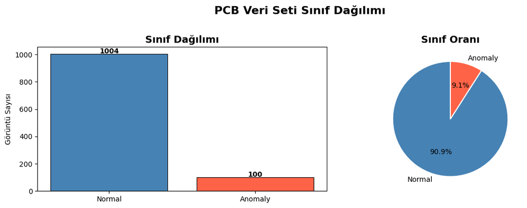

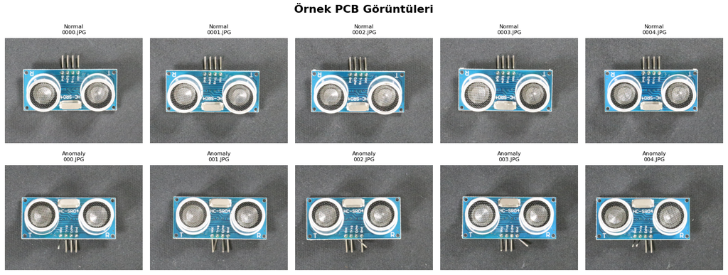

```python
# ── Bölüm 2.4: Veri Keşfi ve Görselleştirme ──────────────────────────────
# Tüm veri setini keşfet
all_paths, all_labels = PCBDataset.discover_files(DATA_ROOT)
n_total   = len(all_labels)
n_normal  = sum(1 for l in all_labels if l == 0)
n_anomaly = sum(1 for l in all_labels if l == 1)

print("=" * 50)
print("VERİ SETİ İSTATİSTİKLERİ")
print("=" * 50)
print(f"Toplam görüntü sayısı : {n_total}")
print(f"Normal görüntü sayısı : {n_normal} ({100*n_normal/n_total:.1f}%)")
print(f"Anomaly görüntü sayısı: {n_anomaly} ({100*n_anomaly/n_total:.1f}%)")
print(f"Sınıf oranı (Normal/Anomaly): {n_normal/n_anomaly:.1f}:1")

# Sınıf dağılımı bar grafiği
fig, axes = plt.subplots(1, 2, figsize=(12, 4))

# Bar grafiği
axes[0].bar(["Normal", "Anomaly"], [n_normal, n_anomaly],
            color=["steelblue", "tomato"], edgecolor="black", linewidth=0.8)
axes[0].set_title("Sınıf Dağılımı", fontsize=14, fontweight="bold")
axes[0].set_ylabel("Görüntü Sayısı")
for i, v in enumerate([n_normal, n_anomaly]):
    axes[0].text(i, v + 5, str(v), ha="center", fontweight="bold")

# Pasta grafiği
axes[1].pie([n_normal, n_anomaly], labels=["Normal", "Anomaly"],
            colors=["steelblue", "tomato"], autopct="%1.1f%%",
            startangle=90, wedgeprops={"edgecolor": "white", "linewidth": 1.5})
axes[1].set_title("Sınıf Oranı", fontsize=14, fontweight="bold")

plt.suptitle("PCB Veri Seti Sınıf Dağılımı", fontsize=16, fontweight="bold", y=1.02)
plt.tight_layout()
plt.show()

# Her sınıftan 5 örnek görüntü göster
normal_paths  = [p for p, l in zip(all_paths, all_labels) if l == 0][:5]
anomaly_paths = [p for p, l in zip(all_paths, all_labels) if l == 1][:5]

fig, axes = plt.subplots(2, 5, figsize=(15, 6))
fig.suptitle("Örnek PCB Görüntüleri", fontsize=16, fontweight="bold")

for i, path in enumerate(normal_paths):
    img = Image.open(path).convert("RGB")
    axes[0, i].imshow(img)
    axes[0, i].set_title(f"Normal\n{os.path.basename(path)}", fontsize=8)
    axes[0, i].axis("off")

for i, path in enumerate(anomaly_paths):
    img = Image.open(path).convert("RGB")
    axes[1, i].imshow(img)
    axes[1, i].set_title(f"Anomaly\n{os.path.basename(path)}", fontsize=8)
    axes[1, i].axis("off")

plt.tight_layout()
plt.show()
```

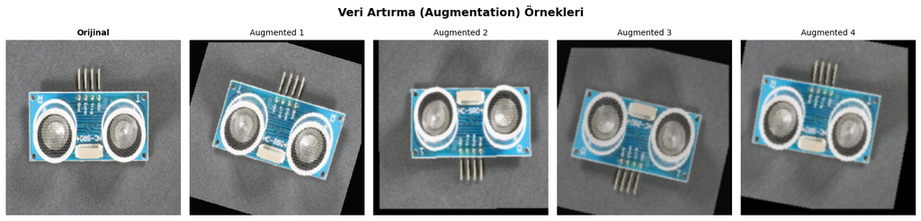

```
Augmentation pipeline: HFlip + VFlip + Rotation(20°) + Affine + ColorJitter + GaussianBlur
```

```python
# ── Bölüm 2.5: Augmentation Pipeline Görselleştirmesi ────────────────────
# Aynı görüntüye 4 farklı augmentation uygulanmış hallerini göster
sample_path = normal_paths[0]
original_img = Image.open(sample_path).convert("RGB")

# Augmentation uygulanmış 4 farklı versiyon oluştur
torch.manual_seed(0)
augmented_versions = []
aug_transform_no_norm = transforms.Compose([
    transforms.Resize((224, 224)),
    transforms.RandomHorizontalFlip(p=0.5),
    transforms.RandomVerticalFlip(p=0.3),
    transforms.RandomRotation(degrees=20),
    transforms.RandomAffine(degrees=0, translate=(0.05, 0.05)),
    transforms.ColorJitter(brightness=0.15, contrast=0.15, saturation=0.1),
    transforms.GaussianBlur(kernel_size=3, sigma=(0.1, 1.0)),
])
for _ in range(4):
    augmented_versions.append(aug_transform_no_norm(original_img))

fig, axes = plt.subplots(1, 5, figsize=(16, 4))
fig.suptitle("Veri Artırma (Augmentation) Örnekleri", fontsize=14, fontweight="bold")

# Orijinal
axes[0].imshow(original_img.resize((224, 224)))
axes[0].set_title("Orijinal", fontsize=10, fontweight="bold")
axes[0].axis("off")

# Augmented versiyonlar
for i, aug_img in enumerate(augmented_versions):
    axes[i+1].imshow(aug_img)
    axes[i+1].set_title(f"Augmented {i+1}", fontsize=10)
    axes[i+1].axis("off")

plt.tight_layout()
plt.show()
print("Augmentation pipeline: HFlip + VFlip + Rotation(20°) + Affine + ColorJitter + GaussianBlur")
```

## Bölüm 3: Model Tasarımı

Bu bölümde iki farklı derin öğrenme mimarisi tanımlanmaktadır: sıfırdan tasarlanmış özel bir CNN ve ResNet-18 tabanlı Transfer Learning modeli. Her modelin parametre sayısı raporlanacak ve mimari detayları açıklanacaktır.

```python
# ── Bölüm 3.1: CustomCNN Sınıfı ───────────────────────────────────────────
class CustomCNN(nn.Module):
    """
    Sıfırdan tasarlanmış özel CNN mimarisi.
    3 evrişimli blok (32→64→128 filtre) + tam bağlantılı sınıflandırıcı başlık.
    Giriş: (B, 3, 224, 224) → Çıkış: (B, 2) ham logit
    """

    def __init__(self, dropout_rate: float = 0.5):
        super(CustomCNN, self).__init__()

        # ── Evrişimli Blok 1: 3 → 32 filtre ──────────────────────────────
        self.block1 = nn.Sequential(
            nn.Conv2d(3, 32, kernel_size=3, padding=1),
            nn.BatchNorm2d(32),
            nn.ReLU(inplace=True),
            nn.MaxPool2d(kernel_size=2, stride=2)   # 224 → 112
        )

        # ── Evrişimli Blok 2: 32 → 64 filtre ─────────────────────────────
        self.block2 = nn.Sequential(
            nn.Conv2d(32, 64, kernel_size=3, padding=1),
            nn.BatchNorm2d(64),
            nn.ReLU(inplace=True),
            nn.MaxPool2d(kernel_size=2, stride=2)   # 112 → 56
        )

        # ── Evrişimli Blok 3: 64 → 128 filtre ────────────────────────────
        self.block3 = nn.Sequential(
            nn.Conv2d(64, 128, kernel_size=3, padding=1),
            nn.BatchNorm2d(128),
            nn.ReLU(inplace=True),
            nn.MaxPool2d(kernel_size=2, stride=2)   # 56 → 28
        )

        # ── Global Havuzlama + Düzleştirme ────────────────────────────────
        self.pool = nn.AdaptiveAvgPool2d((4, 4))    # 28 → 4×4
        # 128 * 4 * 4 = 2048

        # ── Tam Bağlantılı Sınıflandırıcı Başlık ─────────────────────────
        self.classifier = nn.Sequential(
            nn.Flatten(),
            nn.Linear(128 * 4 * 4, 256),
            nn.ReLU(inplace=True),
            nn.Dropout(p=dropout_rate),
            nn.Linear(256, 2)                       # 2 sınıf: Normal(0), Anomaly(1)
        )

    def forward(self, x: torch.Tensor) -> torch.Tensor:
        """Giriş: (B, 3, 224, 224) → Çıkış: (B, 2) ham logit"""
        x = self.block1(x)
        x = self.block2(x)
        x = self.block3(x)
        x = self.pool(x)
        x = self.classifier(x)
        return x  # Ham logit — softmax/sigmoid uygulanmaz

    def count_parameters(self) -> Dict[str, int]:
        """Toplam ve eğitilebilir parametre sayısını döndürür."""
        total     = sum(p.numel() for p in self.parameters())
        trainable = sum(p.numel() for p in self.parameters() if p.requires_grad)
        return {"total": total, "trainable": trainable}


# Model örneği oluştur ve parametre sayısını raporla
cnn_model = CustomCNN(dropout_rate=0.5).to(device)
cnn_params = cnn_model.count_parameters()

print("CustomCNN Mimarisi:")
print(f"  Blok 1 : Conv2d(3→32)   + BatchNorm + ReLU + MaxPool → (B, 32, 112, 112)")
print(f"  Blok 2 : Conv2d(32→64)  + BatchNorm + ReLU + MaxPool → (B, 64,  56,  56)")
print(f"  Blok 3 : Conv2d(64→128) + BatchNorm + ReLU + MaxPool → (B, 128, 28,  28)")
print(f"  Pool   : AdaptiveAvgPool2d(4,4)                       → (B, 128,  4,   4)")
print(f"  FC     : Linear(2048→256) + ReLU + Dropout(0.5) + Linear(256→2)")
print(f"")
print(f"Parametre Sayısı:")
print(f"  Toplam parametre     : {cnn_params['total']:,}")
print(f"  Eğitilebilir parametre: {cnn_params['trainable']:,}")

# Çıktı şeklini doğrula
with torch.no_grad():
    dummy = torch.randn(2, 3, 224, 224).to(device)
    out   = cnn_model(dummy)
print(f"\nÇıktı şekli doğrulaması: giriş (2,3,224,224) → çıkış {tuple(out.shape)} ✓")
```

```
CustomCNN Mimarisi:
  Blok 1 : Conv2d(3→32)   + BatchNorm + ReLU + MaxPool → (B, 32, 112, 112)
  Blok 2 : Conv2d(32→64)  + BatchNorm + ReLU + MaxPool → (B, 64,  56,  56)
  Blok 3 : Conv2d(64→128) + BatchNorm + ReLU + MaxPool → (B, 128, 28,  28)
  Pool   : AdaptiveAvgPool2d(4,4)                       → (B, 128,  4,   4)
  FC     : Linear(2048→256) + ReLU + Dropout(0.5) + Linear(256→2)

Parametre Sayısı:
  Toplam parametre     : 618,754
  Eğitilebilir parametre: 618,754

Çıktı şekli doğrulaması: giriş (2,3,224,224) → çıkış (2, 2) ✓
```

```python
# ── Bölüm 3.2: TransferModel Sınıfı (ResNet-18) ───────────────────────────
class TransferModel(nn.Module):
    """
    ResNet-18 tabanlı Transfer Learning modeli.
    ImageNet ağırlıklarıyla önceden eğitilmiş omurga + yeni sınıflandırıcı başlık.
    Giriş: (B, 3, 224, 224) → Çıkış: (B, 2) ham logit
    """

    def __init__(self, backbone: str = "resnet18", dropout_rate: float = 0.5):
        super(TransferModel, self).__init__()

        # ResNet-18 omurgasını ImageNet ağırlıklarıyla yükle
        self.backbone = models.resnet18(weights=ResNet18_Weights.IMAGENET1K_V1)

        # Orijinal fc başlığını kaldır ve yeni başlıkla değiştir
        in_features = self.backbone.fc.in_features  # 512
        self.backbone.fc = nn.Sequential(
            nn.Linear(in_features, 256),
            nn.ReLU(inplace=True),
            nn.Dropout(p=dropout_rate),
            nn.Linear(256, 2)   # 2 sınıf: Normal(0), Anomaly(1)
        )

    def freeze_backbone(self) -> None:
        """
        conv1, bn1, relu, maxpool, layer1, layer2 katmanlarını dondurur.
        layer3, layer4 ve yeni fc başlığı eğitilebilir kalır.
        """
        # Tüm omurgayı önce dondur
        for param in self.backbone.parameters():
            param.requires_grad = False

        # layer3, layer4 ve yeni fc başlığını eğitilebilir yap
        for layer in [self.backbone.layer3,
                      self.backbone.layer4,
                      self.backbone.fc]:
            for param in layer.parameters():
                param.requires_grad = True

    def forward(self, x: torch.Tensor) -> torch.Tensor:
        """Giriş: (B, 3, 224, 224) → Çıkış: (B, 2) ham logit"""
        return self.backbone(x)  # Ham logit — softmax/sigmoid uygulanmaz

    def count_parameters(self) -> Dict[str, int]:
        """Toplam ve eğitilebilir parametre sayısını döndürür."""
        total     = sum(p.numel() for p in self.parameters())
        trainable = sum(p.numel() for p in self.parameters() if p.requires_grad)
        return {"total": total, "trainable": trainable}


# Model örneği oluştur, omurgayı dondur ve parametre sayısını raporla
transfer_model = TransferModel(backbone="resnet18", dropout_rate=0.5)
transfer_model.freeze_backbone()
transfer_model = transfer_model.to(device)
transfer_params = transfer_model.count_parameters()

print("TransferModel (ResNet-18) Mimarisi:")
print(f"  Dondurulmuş katmanlar : conv1, bn1, relu, maxpool, layer1, layer2")
print(f"  Eğitilebilir katmanlar: layer3, layer4, yeni fc başlığı")
print(f"  Yeni fc başlığı       : Linear(512→256) + ReLU + Dropout(0.5) + Linear(256→2)")
print(f"")
print(f"Parametre Sayısı:")
print(f"  Toplam parametre      : {transfer_params['total']:,}")
print(f"  Eğitilebilir parametre: {transfer_params['trainable']:,}")
print(f"  Dondurulmuş parametre : {transfer_params['total'] - transfer_params['trainable']:,}")

# Çıktı şeklini doğrula
with torch.no_grad():
    dummy = torch.randn(2, 3, 224, 224).to(device)
    out   = transfer_model(dummy)
print(f"\nÇıktı şekli doğrulaması: giriş (2,3,224,224) → çıkış {tuple(out.shape)} ✓")
```

```
TransferModel (ResNet-18) Mimarisi:
  Dondurulmuş katmanlar : conv1, bn1, relu, maxpool, layer1, layer2
  Eğitilebilir katmanlar: layer3, layer4, yeni fc başlığı
  Yeni fc başlığı       : Linear(512→256) + ReLU + Dropout(0.5) + Linear(256→2)

Parametre Sayısı:
  Toplam parametre      : 11,308,354
  Eğitilebilir parametre: 10,625,282
  Dondurulmuş parametre : 683,072

Çıktı şekli doğrulaması: giriş (2,3,224,224) → çıkış (2, 2) ✓
```

## Bölüm 4: Deneysel Çalışmalar

Bu bölümde her iki model eğitilmekte, öğrenme oranı hiperparametre analizi yapılmakta ve eğitim süreçleri kayıt altına alınmaktadır. Early stopping, ReduceLROnPlateau zamanlayıcısı ve en iyi model kaydetme mekanizmaları bu bölümde devreye girmektedir.

```python
class Trainer:
    """
    Model eğitim döngüsünü yöneten sınıf.
    Early stopping, ReduceLROnPlateau ve en iyi model kaydetme içerir.
    """

    def __init__(
        self,
        model: nn.Module,
        device: torch.device,
        class_weights: torch.Tensor = None,
        lr: float = 1e-3,
        max_epochs: int = 50,
        patience: int = 15
    ):
        self.model         = model
        self.device        = device
        self.max_epochs    = max_epochs
        self.patience      = patience

        # Optimizer: yalnızca eğitilebilir parametreler
        self.optimizer = optim.Adam(
            filter(lambda p: p.requires_grad, model.parameters()),
            lr=lr
        )

        # LR Scheduler: doğrulama F1 skoru iyileşmezse LR'yi yarıya indir
        # Not: Early stopping patience (self.patience) scheduler'dan büyük olmalıdır.
        self.scheduler = optim.lr_scheduler.ReduceLROnPlateau(
            self.optimizer, mode='max', factor=0.5, patience=5
        )

        # Ağırlıklı kayıp fonksiyonu
        # Sampler kullanıldığında loss weight kullanmamak daha dengeli bir eğitim sağlar.
        if class_weights is not None:
            self.criterion = nn.CrossEntropyLoss(weight=class_weights.to(device))
        else:
            self.criterion = nn.CrossEntropyLoss()

        # Eğitim süresi takibi
        self.training_time_seconds = 0.0

    def _train_epoch(self, loader: DataLoader) -> Tuple[float, float, float, float]:
        """Bir epoch eğitim yapar. (loss, accuracy) döndürür."""
        self.model.train()
        total_loss, correct, total = 0.0, 0, 0
        all_labels, all_preds = [], []

        for images, labels in loader:
            images = images.to(self.device)
            labels = labels.to(self.device)

            self.optimizer.zero_grad()
            outputs = self.model(images)
            loss    = self.criterion(outputs, labels)
            loss.backward()
            self.optimizer.step()

            total_loss += loss.item() * images.size(0)
            preds       = outputs.argmax(dim=1)
            correct    += (preds == labels).sum().item()
            total      += images.size(0)
            all_preds.extend(preds.cpu().detach().numpy())
            all_labels.extend(labels.cpu().numpy())

        avg_loss = total_loss / total
        accuracy = 100.0 * correct / total
        from sklearn.metrics import recall_score
        rec_0 = recall_score(all_labels, all_preds, pos_label=0, zero_division=0)
        rec_1 = recall_score(all_labels, all_preds, pos_label=1, zero_division=0)
        return avg_loss, accuracy, rec_0, rec_1

    def _validate_epoch(self, loader: DataLoader) -> Tuple[float, float, float, float, float]:
        """Bir epoch doğrulama yapar. (loss, accuracy, recall_0, recall_1, f1_1) döndürür."""
        self.model.eval()
        total_loss, correct, total = 0.0, 0, 0
        all_preds, all_labels = [], []

        with torch.no_grad():
            for images, labels in loader:
                images = images.to(self.device)
                labels = labels.to(self.device)

                outputs    = self.model(images)
                loss       = self.criterion(outputs, labels)
                total_loss += loss.item() * images.size(0)
                preds       = outputs.argmax(dim=1)
                correct    += (preds == labels).sum().item()
                total      += images.size(0)

                all_preds.extend(preds.cpu().numpy())
                all_labels.extend(labels.cpu().numpy())

        avg_loss = total_loss / total
        accuracy = 100.0 * correct / total

        from sklearn.metrics import recall_score, f1_score
        r0 = recall_score(all_labels, all_preds, pos_label=0, zero_division=0)
        r1 = recall_score(all_labels, all_preds, pos_label=1, zero_division=0)
        f1 = f1_score(all_labels, all_preds, pos_label=1, zero_division=0)

        return avg_loss, accuracy, r0, r1, f1

    def _save_best(self, model_name: str) -> None:
        """En iyi model ağırlıklarını diske kaydeder."""
        torch.save(self.model.state_dict(), f"best_{model_name}.pth")

    def train(
        self,
        train_loader: DataLoader,
        val_loader: DataLoader,
        model_name: str
    ) -> Dict[str, List[float]]:
        """
        Modeli eğitir. Eğitim geçmişini döndürür.
        """
        history = {
            "train_loss": [], "val_loss": [],
            "train_acc":  [], "val_acc":  [],
            "val_f1":     []
        }

        best_val_f1      = -1.0
        patience_counter = 0
        start_time       = time.time()

        print(f"\n{'='*60}")
        print(f"Model eğitimi başlıyor: {model_name}")
        print(f"Max epoch: {self.max_epochs} | Early stopping patience: {self.patience}")
        print(f"{'='*60}")
        print(f"{'Epoch':>6} | {'Train Loss':>10} | {'Val Loss':>10} | "
              f"{'Train Acc':>10} | {'Val Acc (R0/R1/F1)':>22}")
        print(f"{'-'*65}")

        for epoch in range(1, self.max_epochs + 1):
            train_loss, train_acc, tr0, tr1 = self._train_epoch(train_loader)
            val_loss, val_acc, r0, r1, val_f1 = self._validate_epoch(val_loader)

            # Geçmişe kaydet
            history["train_loss"].append(train_loss)
            history["val_loss"].append(val_loss)
            history["train_acc"].append(train_acc)
            history["val_acc"].append(val_acc)
            history["val_f1"].append(val_f1)

            # LR Scheduler güncelle
            self.scheduler.step(val_f1)

            # Konsola yazdır
            print(f"{epoch:>6} | {train_loss:>10.4f} | {val_loss:>10.4f} | "
                  f"{train_acc:>9.2f}% | {val_acc:>9.2f}% | R:{r0:.2f}/{r1:.2f} F1:{val_f1:.2f}")

            # En iyi model kontrolü
            if val_f1 > best_val_f1:
                best_val_f1      = val_f1
                patience_counter = 0
                self._save_best(model_name)
            else:
                patience_counter += 1
                if patience_counter >= self.patience:
                    print(f"\nErken durdurma tetiklendi: Epoch {epoch}")
                    break

        # Eğitim süresini raporla
        elapsed = time.time() - start_time
        self.training_time_seconds = elapsed
        mins, secs = divmod(int(elapsed), 60)
        print(f"\nEğitim süresi: {mins} dakika {secs} saniye")
        print(f"En iyi doğrulama Anomali F1 skoru: {best_val_f1:.4f}")
        print(f"Model kaydedildi: best_{model_name}.pth")

        return history
```

```python
# ── Bölüm 4.2: CNN Modeli Eğitimi ─────────────────────────────────────────
# Yeni bir CNN modeli örneği oluştur (tekrarlanabilirlik için seed)
torch.manual_seed(42)
cnn_model = CustomCNN(dropout_rate=0.5).to(device)

# Trainer oluştur ve eğit
cnn_trainer = Trainer(
    model=cnn_model,
    device=device,
    class_weights=None,  # Sampler zaten dengeliyor — çift cezalandırma yok
    lr=1e-3,
    max_epochs=50,
    patience=10
)

cnn_history = cnn_trainer.train(train_loader, val_loader, "cnn")
cnn_training_time = cnn_trainer.training_time_seconds
```

```
============================================================
Model eğitimi başlıyor: cnn
Max epoch: 50 | Early stopping patience: 10
============================================================
 Epoch | Train Loss |   Val Loss |  Train Acc |     Val Acc (R0/R1/F1)
-----------------------------------------------------------------
     1 |     0.6284 |     0.3246 |     74.74% |     90.96% | R:1.00/0.00 F1:0.00
     2 |     0.5783 |     0.3116 |     73.32% |     90.96% | R:1.00/0.00 F1:0.00
     3 |     0.5398 |     0.4200 |     74.48% |     90.96% | R:1.00/0.00 F1:0.00
     4 |     0.5384 |     0.3277 |     75.13% |     90.96% | R:1.00/0.00 F1:0.00
     5 |     0.5034 |     0.2666 |     75.13% |     90.96% | R:1.00/0.00 F1:0.00
     6 |     0.4810 |     0.2908 |     77.59% |     90.96% | R:1.00/0.00 F1:0.00
     7 |     0.4842 |     0.2293 |     76.94% |     90.96% | R:1.00/0.00 F1:0.00
     8 |     0.5048 |     0.3386 |     74.87% |     90.96% | R:1.00/0.00 F1:0.00
     9 |     0.4796 |     0.2528 |     76.42% |     90.96% | R:1.00/0.00 F1:0.00
    10 |     0.4849 |     0.2713 |     75.26% |     90.96% | R:1.00/0.00 F1:0.00
    11 |     0.4735 |     0.2335 |     74.74% |     90.96% | R:1.00/0.00 F1:0.00

Erken durdurma tetiklendi: Epoch 11

Eğitim süresi: 4 dakika 1 saniye
En iyi doğrulama Anomali F1 skoru: 0.0000
Model kaydedildi: best_cnn.pth
```

```python
# ── Bölüm 4.3: Transfer Learning Modeli Eğitimi ───────────────────────────
# Yeni bir TransferModel örneği oluştur
torch.manual_seed(42)
transfer_model = TransferModel(backbone="resnet18", dropout_rate=0.5)
transfer_model.freeze_backbone()
transfer_model = transfer_model.to(device)

# Trainer oluştur ve eğit
transfer_trainer = Trainer(
    model=transfer_model,
    device=device,
    class_weights=class_weights,
    lr=1e-3,
    max_epochs=50,
    patience=10
)

transfer_history = transfer_trainer.train(train_loader, val_loader, "transfer")
transfer_training_time = transfer_trainer.training_time_seconds
```

```
============================================================
Model eğitimi başlıyor: transfer
Max epoch: 50 | Early stopping patience: 10
============================================================
 Epoch | Train Loss |   Val Loss |  Train Acc |     Val Acc (R0/R1/F1)
-----------------------------------------------------------------
     1 |     0.5370 |     0.6163 |     50.78% |     90.96% | R:1.00/0.00 F1:0.00
     2 |     0.3751 |     0.3417 |     72.41% |     73.49% | R:0.71/1.00 F1:0.41
     3 |     0.2850 |     0.3879 |     78.37% |     77.71% | R:0.76/0.93 F1:0.43
     4 |     0.2483 |     1.0252 |     82.90% |     69.88% | R:0.67/1.00 F1:0.38
     5 |     0.2614 |     0.3103 |     79.02% |     71.08% | R:0.68/1.00 F1:0.38
     6 |     0.2225 |     0.8130 |     80.18% |     71.69% | R:0.69/1.00 F1:0.39
     7 |     0.2093 |     0.3610 |     83.29% |     96.99% | R:0.99/0.73 F1:0.81
     8 |     0.2309 |     0.2410 |     83.16% |     94.58% | R:0.97/0.73 F1:0.71
     9 |     0.1345 |     0.4484 |     88.73% |     72.29% | R:0.70/1.00 F1:0.39
```

[output cut: 29 more lines]

```python
# ── Bölüm 4.4: HyperparamAnalyzer Sınıfı ─────────────────────────────────
class HyperparamAnalyzer:
    """
    Öğrenme oranı hiperparametre analizini yürüten sınıf.
    Her LR değeri için bağımsız bir CNN eğitir ve val_f1_weighted kaydeder.
    """

    def __init__(
        self,
        train_loader: DataLoader,
        val_loader: DataLoader,
        class_weights: torch.Tensor,
        device: torch.device
    ):
        self.train_loader  = train_loader
        self.val_loader    = val_loader
        self.class_weights = class_weights
        self.device        = device

    def run_lr_search(
        self,
        lr_values: List[float] = [1e-2, 1e-3, 1e-4],
        max_epochs: int = 10,
        patience: int = 3
    ) -> pd.DataFrame:
        """
        Her LR değeri için bağımsız bir CustomCNN eğitir.
        Döndürür: DataFrame(columns=[learning_rate, val_f1_weighted])
        """
        results = []

        for lr in lr_values:
            print(f"\n{'─'*50}")
            print(f"LR Deneyi: lr={lr}")
            print(f"{'─'*50}")

            # Tekrarlanabilirlik için seed ayarla
            torch.manual_seed(42)
            np.random.seed(42)

            # Yeni model örneği
            model = CustomCNN(dropout_rate=0.5).to(self.device)

            # Trainer ile eğit
            trainer = Trainer(
                model=model,
                device=self.device,
                class_weights=None,
                lr=lr,
                max_epochs=max_epochs,
                patience=patience
            )
            trainer.train(self.train_loader, self.val_loader,
                          model_name=f"lr_search_{lr}")

            # Doğrulama seti üzerinde val_f1_weighted hesapla
            model.eval()
            all_preds, all_labels_list = [], []
            with torch.no_grad():
                for images, labels in self.val_loader:
                    images = images.to(self.device)
                    outputs = model(images)
                    preds   = outputs.argmax(dim=1).cpu().numpy()
                    all_preds.extend(preds)
                    all_labels_list.extend(labels.numpy())

            val_f1 = f1_score(all_labels_list, all_preds,
                              average='weighted', zero_division=0)
            results.append({"learning_rate": lr, "val_f1_weighted": val_f1})
            print(f"  → val_f1_weighted = {val_f1:.4f}")

            # Geçici model dosyasını temizle
            import os as _os
            tmp_file = f"best_lr_search_{lr}.pth"
            if _os.path.exists(tmp_file):
                _os.remove(tmp_file)

        df = pd.DataFrame(results)
        best_row = df.loc[df["val_f1_weighted"].idxmax()]
        print(f"\nEn iyi öğrenme oranı: {best_row['learning_rate']}, "
              f"Doğrulama F1: {best_row['val_f1_weighted']:.4f}")
        return df

    def plot_lr_analysis(self, results: pd.DataFrame) -> None:
        """LR analiz sonuçlarını log-scale x ekseniyle görselleştirir."""
        fig, ax = plt.subplots(figsize=(8, 5))
        ax.plot(results["learning_rate"], results["val_f1_weighted"],
                marker='o', linewidth=2, markersize=8, color='steelblue')

        for _, row in results.iterrows():
            ax.annotate(f"{row['val_f1_weighted']:.3f}",
                        (row['learning_rate'], row['val_f1_weighted']),
                        textcoords="offset points", xytext=(0, 10),
                        ha='center', fontsize=10)

        ax.set_xscale('log')
        ax.set_xlabel('Öğrenme Oranı (log ölçeği)', fontsize=12)
        ax.set_ylabel('Doğrulama Weighted-F1', fontsize=12)
        ax.set_title('Öğrenme Oranı Analizi', fontsize=14, fontweight='bold')
        ax.grid(True, alpha=0.3)
        plt.tight_layout()
        plt.show()


print("HyperparamAnalyzer sınıfı tanımlandı.")
```

```
HyperparamAnalyzer sınıfı tanımlandı.
```

```
──────────────────────────────────────────────────
LR Deneyi: lr=0.01
──────────────────────────────────────────────────

============================================================
Model eğitimi başlıyor: lr_search_0.01
Max epoch: 10 | Early stopping patience: 3
============================================================
 Epoch | Train Loss |   Val Loss |  Train Acc |     Val Acc (R0/R1/F1)
-----------------------------------------------------------------
     1 |     2.5346 |     0.4435 |     65.80% |     90.96% | R:1.00/0.00 F1:0.00
     2 |     0.6084 |     0.4016 |     72.93% |     90.96% | R:1.00/0.00 F1:0.00
     3 |     0.5597 |     0.4884 |     74.61% |     90.96% | R:1.00/0.00 F1:0.00
     4 |     0.5481 |     0.3799 |     75.39% |     90.96% | R:1.00/0.00 F1:0.00

Erken durdurma tetiklendi: Epoch 4

Eğitim süresi: 1 dakika 52 saniye
En iyi doğrulama Anomali F1 skoru: 0.0000
Model kaydedildi: best_lr_search_0.01.pth
  → val_f1_weighted = 0.8666

──────────────────────────────────────────────────
LR Deneyi: lr=0.001
──────────────────────────────────────────────────

============================================================
Model eğitimi başlıyor: lr_search_0.001
Max epoch: 10 | Early stopping patience: 3
============================================================
 Epoch | Train Loss |   Val Loss |  Train Acc |     Val Acc (R0/R1/F1)
-----------------------------------------------------------------
     1 |     0.6284 |     0.3246 |     74.74% |     90.96% | R:1.00/0.00 F1:0.00
     2 |     0.5783 |     0.3116 |     73.32% |     90.96% | R:1.00/0.00 F1:0.00
     3 |     0.5398 |     0.4200 |     74.48% |     90.96% | R:1.00/0.00 F1:0.00
     4 |     0.5384 |     0.3277 |     75.13% |     90.96% | R:1.00/0.00 F1:0.00

Erken durdurma tetiklendi: Epoch 4

Eğitim süresi: 1 dakika 56 saniye
```

[output cut: 14 more lines]

```
     1 |     0.5638 |     0.4317 |     76.55% |     90.96% | R:1.00/0.00 F1:0.00
     2 |     0.5602 |     0.3268 |     73.83% |     90.96% | R:1.00/0.00 F1:0.00
     3 |     0.5423 |     0.4507 |     75.00% |     90.96% | R:1.00/0.00 F1:0.00
     4 |     0.5413 |     0.3422 |     75.13% |     90.96% | R:1.00/0.00 F1:0.00

Erken durdurma tetiklendi: Epoch 4

Eğitim süresi: 1 dakika 53 saniye
En iyi doğrulama Anomali F1 skoru: 0.0000
Model kaydedildi: best_lr_search_0.0001.pth
  → val_f1_weighted = 0.8666

En iyi öğrenme oranı: 0.01, Doğrulama F1: 0.8666

Öğrenme Oranı Analizi Sonuçları:
```

|  | learning_rate | val_f1_weighted |
| --- | --- | --- |
| 0 | 0.0100 | 0.866596 |
| 1 | 0.0010 | 0.866596 |
| 2 | 0.0001 | 0.866596 |

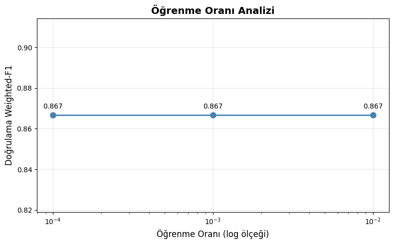

```python
# ── Bölüm 4.5: Öğrenme Oranı Analizi ─────────────────────────────────────
analyzer = HyperparamAnalyzer(
    train_loader=train_loader,
    val_loader=val_loader,
    class_weights=class_weights,
    device=device
)

lr_results = analyzer.run_lr_search(
    lr_values=[1e-2, 1e-3, 1e-4],
    max_epochs=10,
    patience=3
)

print("\nÖğrenme Oranı Analizi Sonuçları:")
display(lr_results)

analyzer.plot_lr_analysis(lr_results)
```

## Bölüm 5: Sonuçlar ve Karşılaştırma

Bu bölümde her iki modelin test seti üzerindeki performansı Accuracy, F1, ROC-AUC ve Precision-Recall metrikleriyle ölçülmektedir. Karışıklık matrisleri, ROC/PR eğrileri ve model karşılaştırma tablosu bu bölümde sunulmaktadır.

```python
# ── Bölüm 5.1: Evaluator Sınıfı ───────────────────────────────────────────
class Evaluator:
    """
    Model değerlendirme sınıfı.
    Test seti üzerinde metrik hesaplama ve görselleştirme yapar.
    """

    def __init__(self, model: nn.Module, device: torch.device,
                 test_loader: DataLoader):
        self.model       = model
        self.device      = device
        self.test_loader = test_loader
        self._preds      = None
        self._probs      = None
        self._labels     = None

    def _run_inference(self, model_name: str) -> None:
        weight_path = f"best_{model_name}.pth"
        if not os.path.exists(weight_path):
            raise FileNotFoundError(
                f"Model ağırlık dosyası bulunamadı: '{weight_path}'. "
                f"Lütfen önce modeli eğitin."
            )
        self.model.load_state_dict(torch.load(weight_path, map_location=self.device))
        self.model.eval()
        all_preds, all_probs, all_labels = [], [], []
        with torch.no_grad():
            for images, labels in self.test_loader:
                images  = images.to(self.device)
                outputs = self.model(images)
                probs   = torch.softmax(outputs, dim=1)[:, 1].cpu().numpy()
                preds   = outputs.argmax(dim=1).cpu().numpy()
                all_preds.extend(preds)
                all_probs.extend(probs)
                all_labels.extend(labels.numpy())
        self._preds  = all_preds
        self._probs  = all_probs
        self._labels = all_labels

    def evaluate(self, model_name: str) -> dict:
        self._run_inference(model_name)
        y_true, y_pred, y_prob = self._labels, self._preds, self._probs
        metrics = {
            "accuracy":           accuracy_score(y_true, y_pred),
            "precision_macro":    precision_score(y_true, y_pred, average='macro',    zero_division=0),
            "precision_weighted": precision_score(y_true, y_pred, average='weighted', zero_division=0),
            "recall_macro":       recall_score(y_true, y_pred, average='macro',    zero_division=0),
            "recall_weighted":    recall_score(y_true, y_pred, average='weighted', zero_division=0),
            "f1_macro":           f1_score(y_true, y_pred, average='macro',    zero_division=0),
            "f1_weighted":        f1_score(y_true, y_pred, average='weighted', zero_division=0),
            "roc_auc":            roc_auc_score(y_true, y_prob),
            "avg_precision":      average_precision_score(y_true, y_prob),
        }
        return metrics

    def plot_confusion_matrix(self, model_name: str) -> None:
        cm = confusion_matrix(self._labels, self._preds)
        fig, ax = plt.subplots(figsize=(6, 5))
        sns.heatmap(cm, annot=True, fmt='d', cmap='Blues',
                    xticklabels=['Normal', 'Anomaly'],
                    yticklabels=['Normal', 'Anomaly'], ax=ax)
        ax.set_xlabel('Tahmin Edilen Etiket', fontsize=12)
        ax.set_ylabel('Gerçek Etiket', fontsize=12)
        ax.set_title(f'Karışıklık Matrisi — {model_name}', fontsize=13, fontweight='bold')
        tn, fp, fn, tp = cm.ravel()
        print(f"  TP={tp}, TN={tn}, FP={fp}, FN={fn}")
        plt.tight_layout()
        plt.show()

    def plot_roc_curves(self, evaluators: list, names: list) -> None:
        fig, ax = plt.subplots(figsize=(7, 6))
        colors = ['steelblue', 'tomato']
        for ev, name, color in zip(evaluators, names, colors):
            fpr, tpr, _ = roc_curve(ev._labels, ev._probs)
            auc_val = roc_auc_score(ev._labels, ev._probs)
            ax.plot(fpr, tpr, color=color, linewidth=2, label=f'{name} (AUC={auc_val:.3f})')
        ax.plot([0, 1], [0, 1], 'k--', linewidth=1, label='Rastgele Sınıflandırıcı')
        ax.set_xlabel('Yanlış Pozitif Oranı (FPR)', fontsize=12)
        ax.set_ylabel('Doğru Pozitif Oranı (TPR)', fontsize=12)
        ax.set_title('ROC Eğrileri', fontsize=14, fontweight='bold')
        ax.legend(fontsize=11)
        ax.grid(True, alpha=0.3)
        plt.tight_layout()
        plt.show()

    def plot_pr_curves(self, evaluators: list, names: list) -> None:
        fig, ax = plt.subplots(figsize=(7, 6))
        colors = ['steelblue', 'tomato']
        for ev, name, color in zip(evaluators, names, colors):
            prec, rec, _ = precision_recall_curve(ev._labels, ev._probs)
            ap = average_precision_score(ev._labels, ev._probs)
            ax.plot(rec, prec, color=color, linewidth=2, label=f'{name} (AP={ap:.3f})')
        ax.set_xlabel('Recall', fontsize=12)
        ax.set_ylabel('Precision', fontsize=12)
        ax.set_title('Precision-Recall Eğrileri', fontsize=14, fontweight='bold')
        ax.legend(fontsize=11)
        ax.grid(True, alpha=0.3)
        plt.tight_layout()
        plt.show()

    def plot_misclassified(self, model_name: str, n: int = 5) -> None:
        test_paths = self.test_loader.dataset.image_paths
        y_true, y_pred = self._labels, self._preds
        fp_indices = [i for i, (t, p) in enumerate(zip(y_true, y_pred)) if t == 0 and p == 1]
        fn_indices = [i for i, (t, p) in enumerate(zip(y_true, y_pred)) if t == 1 and p == 0]
        for error_type, indices, true_lbl, pred_lbl in [
            ('False Positive (Normal → Anomaly)', fp_indices, 'Normal', 'Anomaly'),
            ('False Negative (Anomaly → Normal)', fn_indices, 'Anomaly', 'Normal')
        ]:
            sample = indices[:n]
            if not sample:
                print(f"  {error_type}: Örnek bulunamadı.")
                continue
            cols = len(sample)
            fig, axes = plt.subplots(1, cols, figsize=(3 * cols, 3))
            if cols == 1:
                axes = [axes]
            fig.suptitle(f'{model_name} — {error_type}', fontsize=12, fontweight='bold')
            for ax, idx in zip(axes, sample):
                img = Image.open(test_paths[idx]).convert('RGB')
                ax.imshow(img)
                ax.set_title(f'Gerçek: {true_lbl}\nTahmin: {pred_lbl}', fontsize=8)
                ax.axis('off')
            plt.tight_layout()
            plt.show()

    def plot_training_history(self, history: dict, model_name: str) -> None:
        epochs = range(1, len(history['train_loss']) + 1)
        fig, axes = plt.subplots(1, 2, figsize=(14, 5))
        fig.suptitle(f'Eğitim Geçmişi — {model_name}', fontsize=14, fontweight='bold')
        axes[0].plot(epochs, history['train_loss'], 'b-', linewidth=2, label='Eğitim Kaybı')
        axes[0].plot(epochs, history['val_loss'],   'r-', linewidth=2, label='Doğrulama Kaybı')
        overfit_epochs = [
            e for e, (ta, va) in enumerate(zip(history['train_acc'], history['val_acc']), 1)
            if ta - va > 10.0
        ]
        for ep in overfit_epochs:
            axes[0].axvline(x=ep, color='orange', linestyle='--', alpha=0.5)
        axes[0].set_xlabel('Epoch', fontsize=11)
        axes[0].set_ylabel('Kayıp', fontsize=11)
        axes[0].set_title('Kayıp Eğrisi', fontsize=12)
        axes[0].legend(fontsize=10)
        axes[0].grid(True, alpha=0.3)
        axes[1].plot(epochs, history['train_acc'], 'b-', linewidth=2, label='Eğitim Doğruluğu')
        axes[1].plot(epochs, history['val_acc'],   'r-', linewidth=2, label='Doğrulama Doğruluğu')
        axes[1].set_xlabel('Epoch', fontsize=11)
        axes[1].set_ylabel('Doğruluk (%)', fontsize=11)
        axes[1].set_title('Doğruluk Eğrisi', fontsize=12)
        axes[1].legend(fontsize=10)
        axes[1].grid(True, alpha=0.3)
        plt.tight_layout()
        plt.show()
        n_last = min(5, len(history['train_loss']))
        gap = (sum(history['train_loss'][-n_last:]) / n_last -
               sum(history['val_loss'][-n_last:]) / n_last)
        print(f"Overfitting gap (son {n_last} epoch ortalaması): {gap:.4f}")
        if overfit_epochs:
            print(f"Overfitting eşiği (>10pp) aşılan epoch'lar: {overfit_epochs}")
        else:
            print("Overfitting eşiği aşılmadı")


print("Evaluator sınıfı tanımlandı.")
```

```
Evaluator sınıfı tanımlandı.
```

```
CNN Modeli — Eğitim Geçmişi:
```

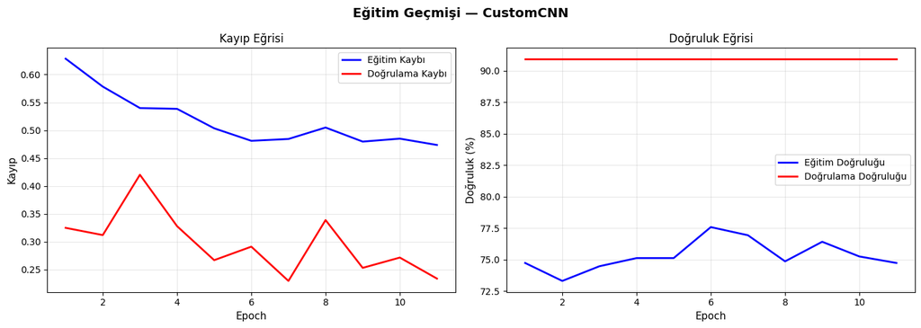

```
Overfitting gap (son 5 epoch ortalaması): 0.2203
Overfitting eşiği aşılmadı

Transfer Learning Modeli — Eğitim Geçmişi:
```

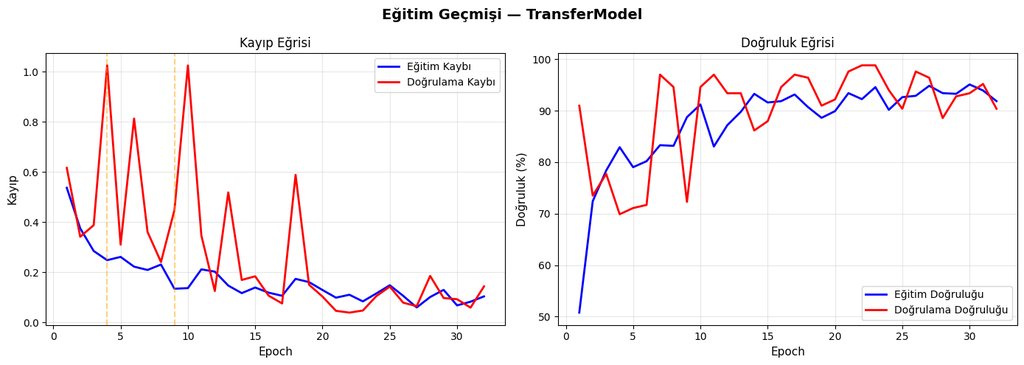

```
Overfitting gap (son 5 epoch ortalaması): -0.0185
Overfitting eşiği (>10pp) aşılan epoch'lar: [4, 9]

============================================================
OVERFİTTİNG ANALİZİ ÖZETİ
============================================================

CustomCNN:
  Toplam epoch sayısı    : 11
  Overfitting gap        : 0.2203
  Overfitting eşiği aşıldı: Hayır
  Dropout katmanı        : Evet (p=0.5)

TransferModel:
  Toplam epoch sayısı    : 32
  Overfitting gap        : -0.0185
  Overfitting eşiği aşıldı: Evet — epoch [4, 9]
  Dropout katmanı        : Evet (p=0.5)
```

```python
# ── Bölüm 5.2: Overfitting Analizi ────────────────────────────────────────
print("CNN Modeli — Eğitim Geçmişi:")
cnn_eval_tmp = Evaluator(cnn_model, device, test_loader)
cnn_eval_tmp.plot_training_history(cnn_history, "CustomCNN")

print("\nTransfer Learning Modeli — Eğitim Geçmişi:")
transfer_eval_tmp = Evaluator(transfer_model, device, test_loader)
transfer_eval_tmp.plot_training_history(transfer_history, "TransferModel")

print("\n" + "="*60)
print("OVERFİTTİNG ANALİZİ ÖZETİ")
print("="*60)
for name, history in [("CustomCNN", cnn_history), ("TransferModel", transfer_history)]:
    n_last = min(5, len(history['train_loss']))
    gap = (sum(history['train_loss'][-n_last:]) / n_last -
           sum(history['val_loss'][-n_last:]) / n_last)
    overfit_epochs = [
        e for e, (ta, va) in enumerate(zip(history['train_acc'], history['val_acc']), 1)
        if ta - va > 10.0
    ]
    print(f"\n{name}:")
    print(f"  Toplam epoch sayısı    : {len(history['train_loss'])}")
    print(f"  Overfitting gap        : {gap:.4f}")
    print(f"  Overfitting eşiği aşıldı: {'Evet — epoch ' + str(overfit_epochs) if overfit_epochs else 'Hayır'}")
    print(f"  Dropout katmanı        : Evet (p=0.5)")
```

```
CNN Modeli değerlendiriliyor...

Transfer Learning Modeli değerlendiriliyor...

--- Karışıklık Matrisleri ---
  TP=0, TN=151, FP=0, FN=15
```

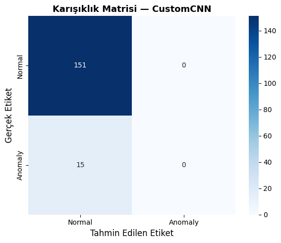

```
  TP=12, TN=146, FP=5, FN=3
```

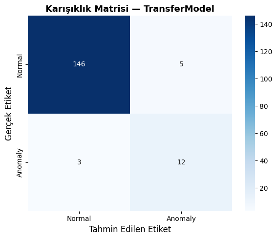

```
--- ROC Eğrileri ---
```

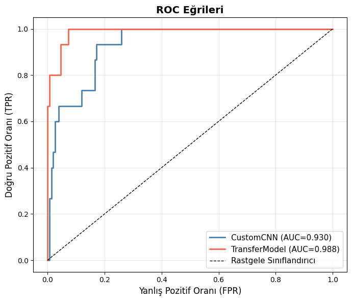

```
--- Precision-Recall Eğrileri ---
```

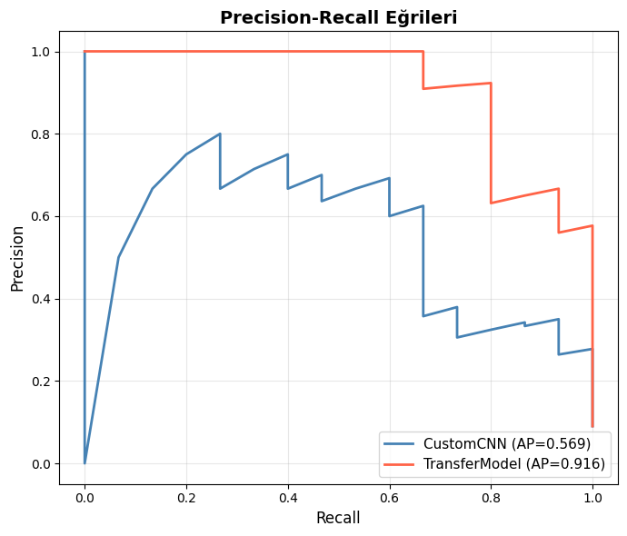

```
--- Model Karşılaştırma Tablosu ---
```

|  | Metrik | CustomCNN | TransferModel |
| --- | --- | --- | --- |
| 0 | Accuracy | 0.9096 | 0.9518 |
| 1 | Macro-F1 | 0.4763 | 0.8617 |
| 2 | Weighted-F1 | 0.8666 | 0.9532 |
| 3 | ROC-AUC | 0.9302 | 0.9881 |
| 4 | Avg Precision | 0.5692 | 0.9156 |

```python
# ── Bölüm 5.3: Performans Değerlendirmesi ─────────────────────────────────
print("CNN Modeli değerlendiriliyor...")
cnn_eval = Evaluator(cnn_model, device, test_loader)
cnn_metrics = cnn_eval.evaluate("cnn")

print("\nTransfer Learning Modeli değerlendiriliyor...")
transfer_eval = Evaluator(transfer_model, device, test_loader)
transfer_metrics = transfer_eval.evaluate("transfer")

print("\n--- Karışıklık Matrisleri ---")
cnn_eval.plot_confusion_matrix("CustomCNN")
transfer_eval.plot_confusion_matrix("TransferModel")

print("\n--- ROC Eğrileri ---")
cnn_eval.plot_roc_curves([cnn_eval, transfer_eval], ["CustomCNN", "TransferModel"])

print("\n--- Precision-Recall Eğrileri ---")
cnn_eval.plot_pr_curves([cnn_eval, transfer_eval], ["CustomCNN", "TransferModel"])

print("\n--- Model Karşılaştırma Tablosu ---")
comparison_df = pd.DataFrame({
    "Metrik": ["Accuracy", "Macro-F1", "Weighted-F1", "ROC-AUC", "Avg Precision"],
    "CustomCNN": [
        f"{cnn_metrics['accuracy']:.4f}",
        f"{cnn_metrics['f1_macro']:.4f}",
        f"{cnn_metrics['f1_weighted']:.4f}",
        f"{cnn_metrics['roc_auc']:.4f}",
        f"{cnn_metrics['avg_precision']:.4f}",
    ],
    "TransferModel": [
        f"{transfer_metrics['accuracy']:.4f}",
        f"{transfer_metrics['f1_macro']:.4f}",
        f"{transfer_metrics['f1_weighted']:.4f}",
        f"{transfer_metrics['roc_auc']:.4f}",
        f"{transfer_metrics['avg_precision']:.4f}",
    ]
})
display(comparison_df)
```

```
Detaylı Model Karşılaştırma Tablosu:
```

|  | Model Adı | Toplam Parametre | Eğitilebilir Parametre | Eğitim Süresi (dk) | Test Macro-F1 | Test ROC-AUC |
| --- | --- | --- | --- | --- | --- | --- |
| 0 | CustomCNN | 618,754 | 618,754 | 4.0 | 0.4763 | 0.9302 |
| 1 | TransferModel | 11,308,354 | 10,625,282 | 14.8 | 0.8617 | 0.9881 |

```
--- Yanlış Sınıflandırılan Görüntüler: CustomCNN ---
  False Positive (Normal → Anomaly): Örnek bulunamadı.
```

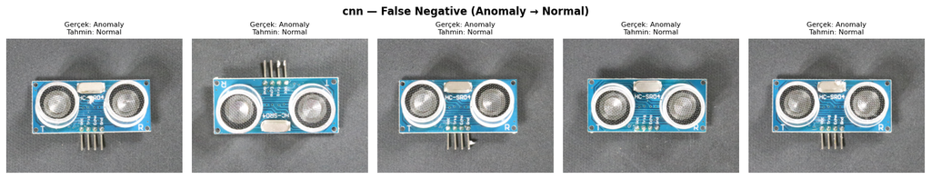

```
--- Yanlış Sınıflandırılan Görüntüler: TransferModel ---
```

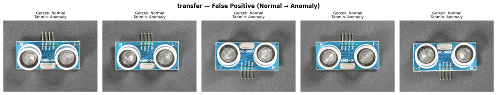

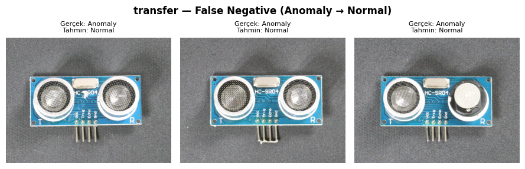

```python
# ── Bölüm 5.4: Detaylı Model Karşılaştırması ──────────────────────────────
cnn_p      = cnn_model.count_parameters()
transfer_p = transfer_model.count_parameters()

detail_df = pd.DataFrame([
    {
        "Model Adı":             "CustomCNN",
        "Toplam Parametre":       f"{cnn_p['total']:,}",
        "Eğitilebilir Parametre": f"{cnn_p['trainable']:,}",
        "Eğitim Süresi (dk)":     f"{cnn_training_time/60:.1f}",
        "Test Macro-F1":          f"{cnn_metrics['f1_macro']:.4f}",
        "Test ROC-AUC":           f"{cnn_metrics['roc_auc']:.4f}",
    },
    {
        "Model Adı":             "TransferModel",
        "Toplam Parametre":       f"{transfer_p['total']:,}",
        "Eğitilebilir Parametre": f"{transfer_p['trainable']:,}",
        "Eğitim Süresi (dk)":     f"{transfer_training_time/60:.1f}",
        "Test Macro-F1":          f"{transfer_metrics['f1_macro']:.4f}",
        "Test ROC-AUC":           f"{transfer_metrics['roc_auc']:.4f}",
    }
])
print("Detaylı Model Karşılaştırma Tablosu:")
display(detail_df)

print("\n--- Yanlış Sınıflandırılan Görüntüler: CustomCNN ---")
cnn_eval.plot_misclassified("cnn", n=5)

print("\n--- Yanlış Sınıflandırılan Görüntüler: TransferModel ---")
transfer_eval.plot_misclassified("transfer", n=5)
```

## Bölüm 6: Tartışma

Bu bölümde overfitting analizi yapılmakta, yanlış sınıflandırılan örnekler incelenmekte ve iki model arasında kanıta dayalı bir karşılaştırma sunulmaktadır. Sınıf dengesizliğinin model performansına etkisi ΔPrecision ve ΔRecall değerleriyle sayısal olarak tartışılmaktadır.

```python
# ── Bölüm 6.1: Model Öneri Mantığı ve Tartışma ────────────────────────────
cnn_f1      = cnn_metrics['f1_macro']
transfer_f1 = transfer_metrics['f1_macro']
f1_diff     = abs(cnn_f1 - transfer_f1)

print("="*60)
print("MODEL ÖNERİSİ")
print("="*60)
print(f"  CustomCNN     Macro-F1: {cnn_f1:.4f}")
print(f"  TransferModel Macro-F1: {transfer_f1:.4f}")
print(f"  F1 farkı              : {f1_diff:.4f}")

if f1_diff >= 0.05:
    winner = "TransferModel" if transfer_f1 > cnn_f1 else "CustomCNN"
    print(f"\n→ F1 farkı >= 0.05: Daha yüksek F1'li model önerilir: {winner}")
    print(f"  Gerekçe: {f1_diff:.4f} puanlık anlamlı performans farkı mevcuttur.")
else:
    cnn_p_count = cnn_model.count_parameters()['trainable']
    trf_p_count = transfer_model.count_parameters()['trainable']
    winner = "CustomCNN" if cnn_p_count < trf_p_count else "TransferModel"
    print(f"\n→ F1 farkı < 0.05: Daha az parametreli model önerilir: {winner}")
    print(f"  Gerekçe: Performans farkı ihmal edilebilir ({f1_diff:.4f}), hafif model tercih edilir.")

print("\n" + "="*60)
print("SINIF DENGESİZLİĞİNİN ETKİSİ")
print("="*60)
delta_precision = cnn_metrics['precision_macro'] - transfer_metrics['precision_macro']
delta_recall    = cnn_metrics['recall_macro']    - transfer_metrics['recall_macro']
print(f"  CustomCNN     Precision(macro): {cnn_metrics['precision_macro']:.4f}  Recall(macro): {cnn_metrics['recall_macro']:.4f}")
print(f"  TransferModel Precision(macro): {transfer_metrics['precision_macro']:.4f}  Recall(macro): {transfer_metrics['recall_macro']:.4f}")
print(f"  DeltaPrecision (CNN - Transfer): {delta_precision:+.4f}")
print(f"  DeltaRecall    (CNN - Transfer): {delta_recall:+.4f}")
if abs(delta_recall) > abs(delta_precision):
    print("\n→ Sinif dengesizligi Recall uzerinde daha belirgin etki gostermistir.")
else:
    print("\n→ Sinif dengesizligi Precision uzerinde daha belirgin etki gostermistir.")
```

```
============================================================
MODEL ÖNERİSİ
============================================================
  CustomCNN     Macro-F1: 0.4763
  TransferModel Macro-F1: 0.8617
  F1 farkı              : 0.3853

→ F1 farkı >= 0.05: Daha yüksek F1'li model önerilir: TransferModel
  Gerekçe: 0.3853 puanlık anlamlı performans farkı mevcuttur.

============================================================
SINIF DENGESİZLİĞİNİN ETKİSİ
============================================================
  CustomCNN     Precision(macro): 0.4548  Recall(macro): 0.5000
  TransferModel Precision(macro): 0.8429  Recall(macro): 0.8834
  DeltaPrecision (CNN - Transfer): -0.3881
  DeltaRecall    (CNN - Transfer): -0.3834

→ Sinif dengesizligi Precision uzerinde daha belirgin etki gostermistir.
```